# Tracking Smart Phone Usage With the Moment App

Joseph Walker - jpwalker625@gmail.com

2017-04-21

# Introduction

Over the past decade, the use of mobile technology has expanded at an unprecedented rate. All around the world, people are relying more heavily on these so called ‘smart phones’ to guide them through their daily lives. These compact, yet powerful devices give us an infinte amount of data at the touch of our fingertips. Like a high-tech swiss army knife, they are equipped with apps that help us keep in touch with friends, stay updated on news, schedule our lives, track our vitals, etc… If you can think of a need, there’s probably an app for it. More likely, there’s a highly addictive app that you probably don’t need! Whatever the case may be, I find myself and those around me ever more distracted by our devices. Like a bug buzzing toward the light, we are drawn to the luminescence of our screens.

Luckily, there’s an app to help with that!

Moment® is an app for the iphone that tracks how much you use your phone each day. It is easy to use and has features to help you limit your phone use. Here’s how it works:

Each morning when you wake up, and every evening before bed, all you have to do is take a screenshot of your phone’s battery information. The moment app automatically detects the screenshots and does the rest.

For more information about the app and where to download it, check out the website:

[figure not shown]

# The Data

I decided to test out the app for a month to get a handle on my own usage. The app even allows you to export your data in JSON format to explore for yourself. Let’s dive into the data to see how it all panned out!

# Pickups

The **pickups** portion of the data tracks information related to each time you pick up your phone.

```
## Observations: 894
## Variables: 9
## $ document.id                 <int> 1, 1, 1, 1, 1, 1, 1, 1, 1, 1, 1, 1...
## $ array.index                 <int> 1, 2, 3, 4, 5, 6, 7, 8, 9, 10, 11,...
## $ location_accuracy_in_meters <dbl> 65.00000, 65.00000, 65.00000, 65.0...
## $ longitude                   <dbl> -122.3876, -122.3877, -122.3876, -...
## $ end_battery_level           <dbl> 0.47, 0.47, 1.00, 1.00, 0.87, 0.85...
## $ length_in_seconds           <dbl> 27, 33, 5, 20, 1884, 99, 37, 93, 8...
## $ date                        <chr> "2017-04-15T00:01:55-07:00", "2017...
## $ latitude                    <dbl> 37.59225, 37.59225, 37.59234, 37.5...
## $ start_battery_level         <dbl> 0.48, 0.47, 1.00, 1.00, 1.00, 0.86...
```

## Daily Usage

### Pickups per Day

On average, I use my phone 26.29 times per day

April 3rd and 4th appear to be outliers; I used my phone much more than usual on those days. This was due to a series of car issues I had that morning which took the most of the day and part of Tuesday to take care of!

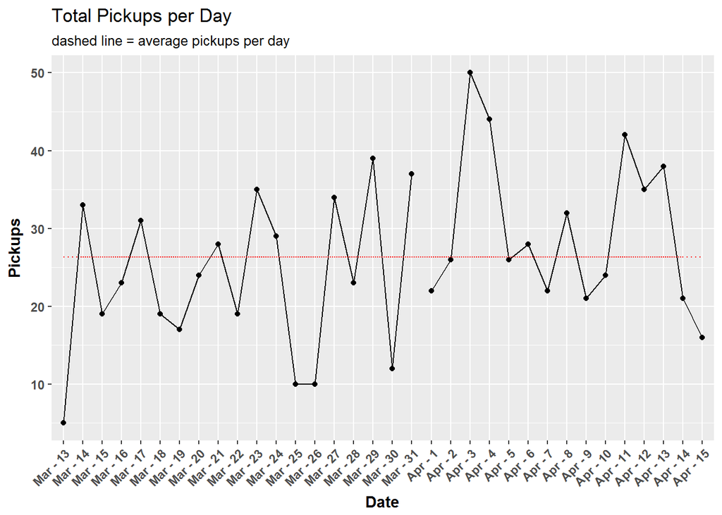

### Time Spent on Phone per Day

On average, I used my phone 73.46 minutes per day.

Again, I spent a significantly longer amount of time dealing with car troubles on April 3rd.

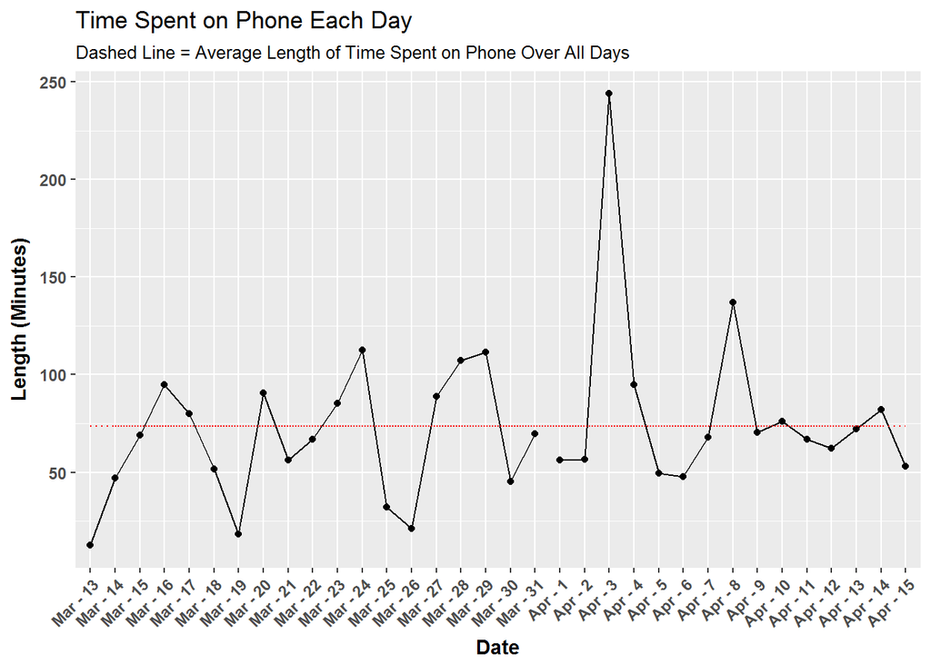

### Average per Pickup

I spend about 2.79 minutes every time I pick up my phone. Later on, we’ll explore what apps I’m using to make more sense of this.

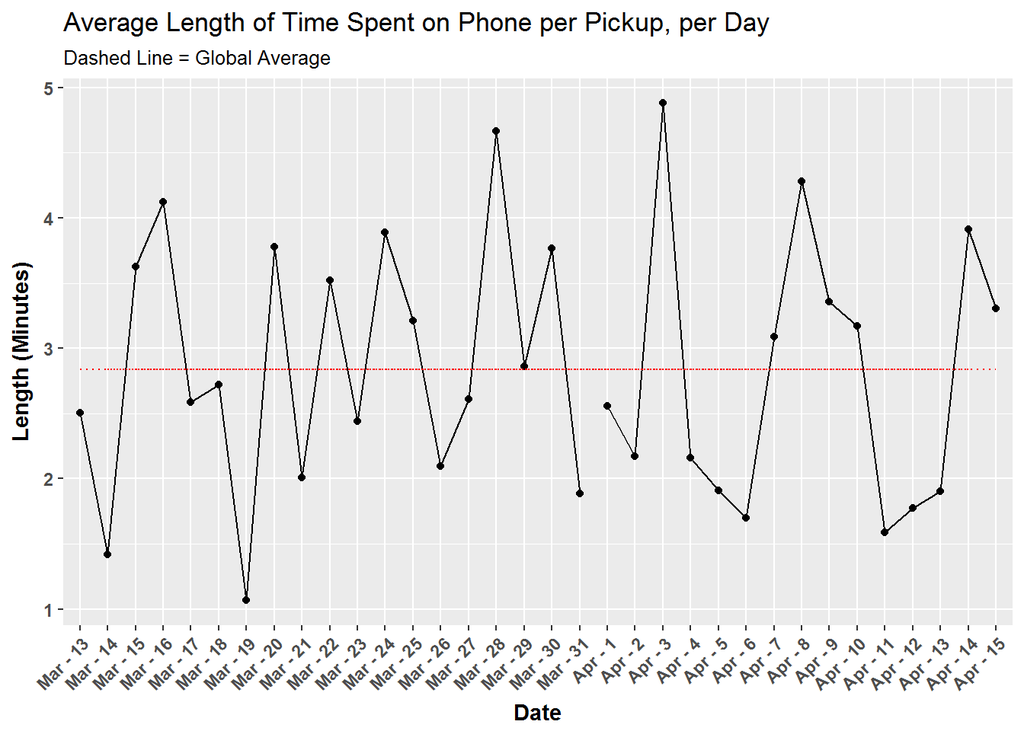

## By Weekday

Let’s take a look to see if there are any trends in phone use based on the weekday.

*I filtered out April 3rd since it isn’t representative of my normal usage.*

### Pickups

It looks like Tuesdays have a lot going on!

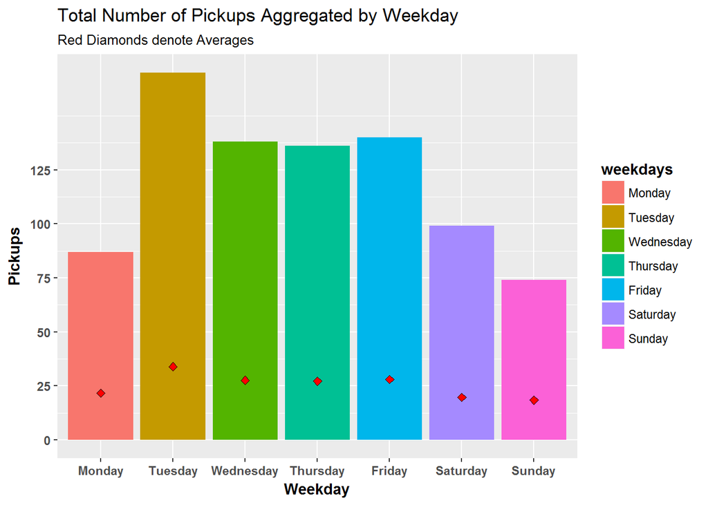

### Time Spent

On second thought, Fridays appear to be the days in which I’m using my phone the most in terms of time spent. Even though I’m picking up my phone more on Tuesdays, I don’t seem to be spending as much time on each pickup. Whether this is due to little distractions or because I’m using it for tasking/scheduling purposes is less clear. Looking at what apps I’m using will help to figure this out.

Overall, I’m using my phone less on the weekends. i’m glad to see this trend; any where I can cut down on phone use and focus on the present is a step in the right direction.

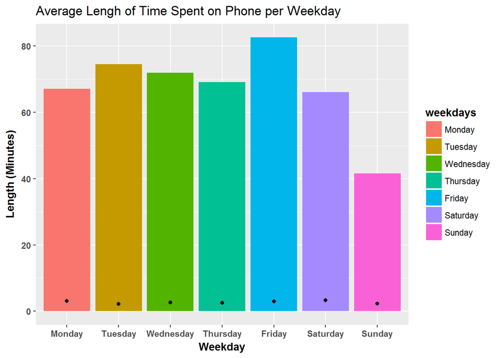

### Average Time per Pickup

I spend about 2-3 minutes on my phone every time I pick it up, regardless of the week day. I am a bit surprised to see that I spend the long time per pickup on Saturdays, even though I use my phone less on Saturdays overall.

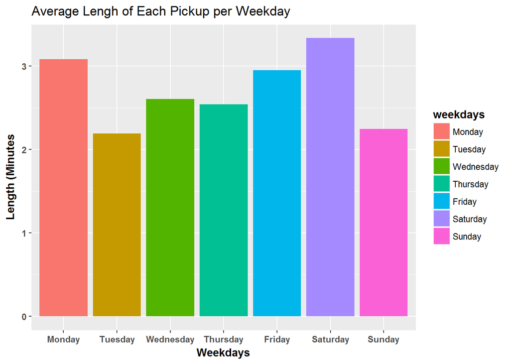

# Apps

Now, let’s explore which Apps I use.

```
## Observations: 382
## Variables: 5
## $ document.id <int> 1, 1, 1, 1, 1, 1, 1, 1, 1, 1, 1, 1, 1, 1, 1, 1, 1,...
## $ array.index <int> 1, 2, 3, 4, 5, 6, 7, 8, 9, 10, 11, 12, 1, 2, 3, 4,...
## $ date        <chr> "2017-04-14T00:00:00-07:00", "2017-04-14T00:00:00-...
## $ app_name    <chr> "Phone", "Home & Lock Screen", "Facebook", "Messag...
## $ on_screen   <dbl> 19, 13, 8, 7, 3, 2, 2, 1, 1, 1, 1, 1, 25, 21, 20, ...
```

In total, I used 43 apps throughout the experiment.

## App Usage by Count

It makes sense that the home and lock screen would be the app I most use since it is literally the first screen that pops up when I need to use my phone.

Looking at the data, the top 10 apps indicate that I’m using my phone primarily for social media - Snapchat, Messages, Facebook, and Instagram - and for web browsing and productivity apps related to work - Chrome, Calendar, and Mail.

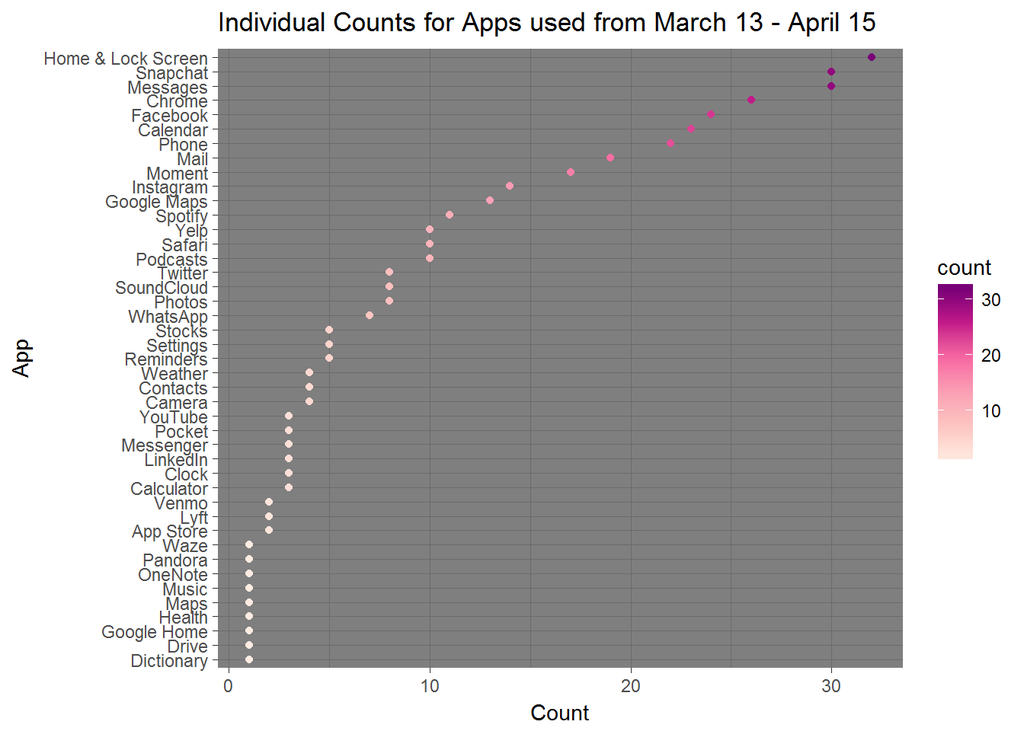

## App Usage by Time

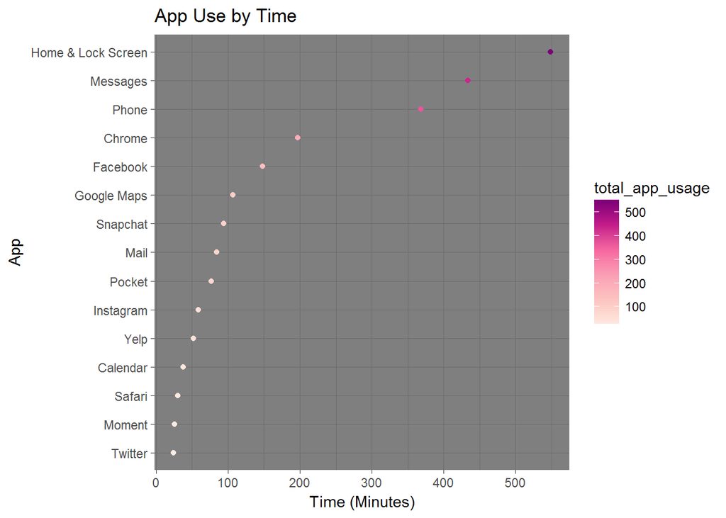

## Avg. App Time per Use

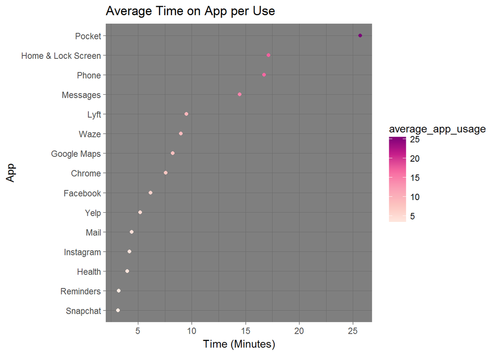

# Predicting Phone Usage

Are there certain times of the day when I use my phone more often than others? This is the question I will seek to address in the following section.

First, I need to break up the date-time into sections:

- morning
- mid-day
- afternoon
- evening

And then I will build a linear model to determine or ‘predict’ how long I am on my phone based on the time of day.

```
## [1] "afternoon" "evening"   "mid-day"   "morning"
```

## Linear Model 1

Here are the components of the linear model:

response variable: length_in_minutes  
predictors: weekdays * time_of_day

( * denotes a crossed interaction between the variables, since there is data for every occurrence of an interaction between the day and time of day)

The model I have used to make the predictions is not very good at all. In fact, it’s terrible.  
The low r squared value of 0.03 signifies that the predictors, i.e. the explanatory variables don’t do a very good job of explaining the data at all. In other words, most of the variation in the data is coming from other variables. Knowing the weekday and the time of day don’t necessarily give me a good idea of how much time I spend on my phone.

In a good model, we would expect to see a random distribution of the residuals. However, there is a trend of high outliers, that isn’t accounted for by the weekday or the time of day.

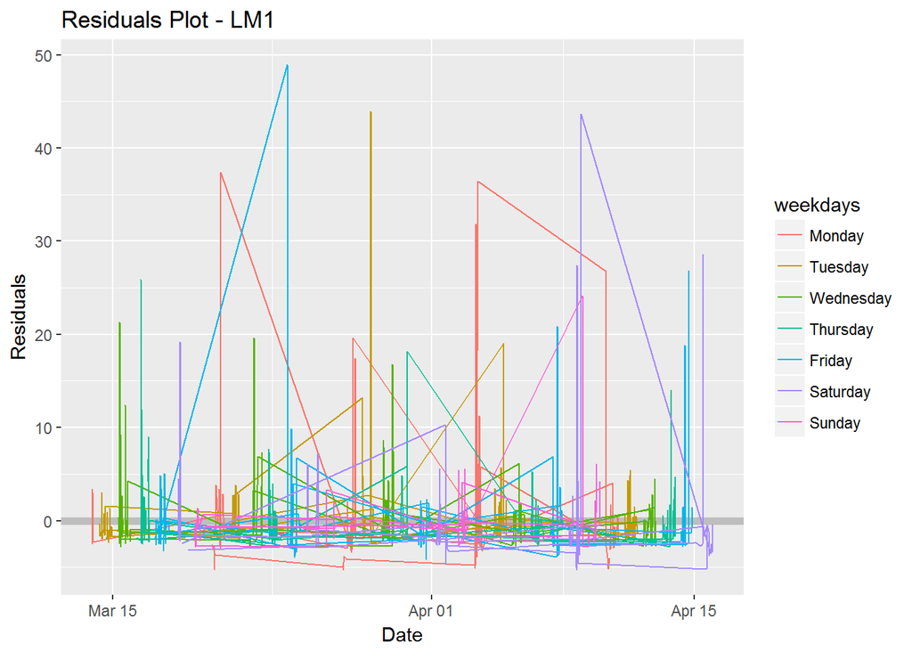

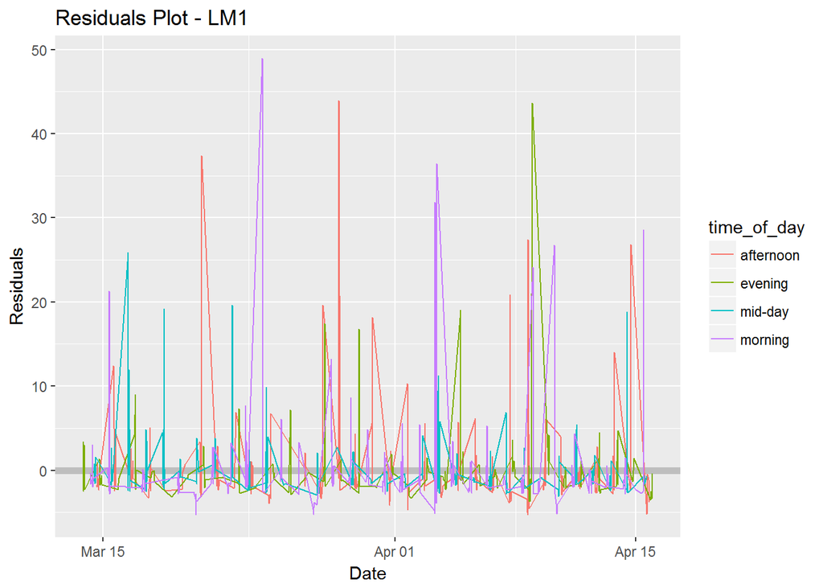

## Linear Model 2

Perhaps I can refine the model by adding a predictor. Does the battery use give me a better idea of how much time I spend on my phone? One should hope so.

The components for model 2 are:

response variable: length_in_minutes  
predictors: weekdays * time_of_day + battery_use

To avoid over fitting, we are looking only at the main effect of battery use. It is not crossed because every level of battery use is not represented on a specific day/time of day interaction.

### Residuals

*Spoiler Alert*

While battery use does improve the fit of the model, an rsquare of 0.18 is still not a great fit. If I were a betting man, I’d be out a lot of money trying to guess how much time I spend on my phone using the predicted values of my model.

I speculate that the app that I’m using has a much greater determination of how long I’m spending on my phone. Unfortunately, the Moment data does not allow me to connect which app I’m using for a particular pickup. The app only tracks the on-screen time for a particular app and isn’t accurate enough to merge to the length of a particular pickup.

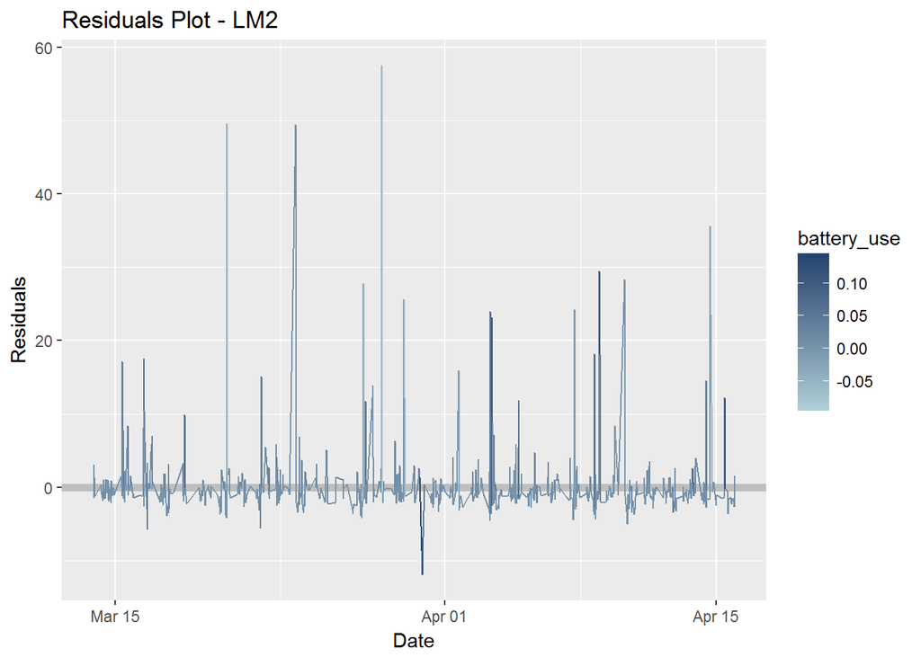

### Predictions

Let’s look at the actual vs. predicted values to visualize why we can’t rely on the model.

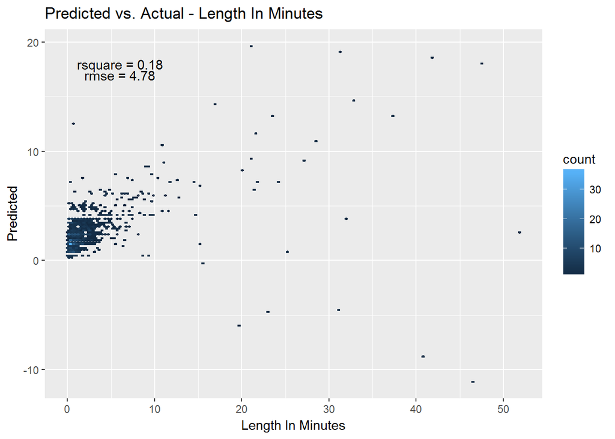

### Predictions - Zoomed

If the model fit the data, we’d expect to see is a linear relationship where the predicted value was as close or equal to the actual value. Zooming in on the above plot to the bulk of the data, we can see there is very little correlation. The blue line represents the slope, which is dramatically off set. The dashed red line represents an ideal slope where we would like to see most of the points on or around.

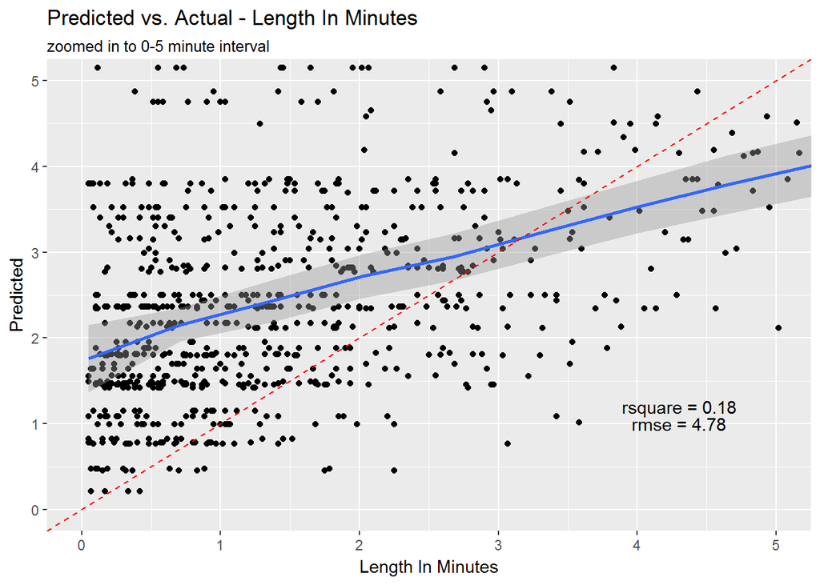

# Shiny App

For your visual entertainment, please follow the link below to check out the shiny app which shows the location of a pickup, and tells you how long the pickup occurred and what percentage of battery was used. There is also a data table with the associated that is filtered to the specific day and time of day you choose.

[Shiny App - Using the Moment App to Track Phone Use](https://tictacjoe.shinyapps.io/moment_app_phone_usage/)